# COX

- Show All Code
- Hide All Code
- View Source

Author

ruinan

```r
library(DT)
library(dplyr)
library(survival)
library(survminer)
```

# 1. Data Input and Preprocessing

The top 200 differentially expressed genes were read from top_200_genes_timepoints.comsv and the top 50 most significant genes were selected in ascending order of P-value. After merging, the required time (time), events (status), and sample feature variables for constructing the Cox model.

```r
top200_path <- "E:/data3888/65391/65391/dataset/top_200_genes_two_timepoints.csv"
top200 <- read.csv(top200_path)


pData_path <- "E:/data3888/65391/65391/dataset/pData_final.rds"
pData <- readRDS(pData_path)


eMat_path <- "E:/data3888/65391/65391/dataset/eMat_with_symbols.rds"
eMat <- readRDS(eMat_path)
```

```r
#chunk2

top_genes <- top200 %>%
  arrange(P.Value) %>%
  pull(X) %>%
  head(50)

genes_to_use <- intersect(top_genes, rownames(eMat))
eMat_subset <- eMat[genes_to_use, ]


eMat_transposed <- as.data.frame(t(eMat_subset))
eMat_transposed$sample_id <- rownames(eMat_transposed)
```

# 2、 Model establishment

Model used: We use the Cox Proportional Hazards Model to process time and event status (whether flare occurs) in survival data.

Composition of characteristic variables: One clinical indicator: SLEDAI score

Gene expression characteristics: The portion of the first 50 differentially expressed genes that actually appear in the expression matrix (ultimately approximately 40+genes)

Construction process: Merge the expression matrix with the clinical information table to form a DataFrame containing all features.

Construct Cox model formula using Surv (time, status)~sledai+gene1+gene2+.

Fit the model using the coxph() function.

```r
#chunk3

library(dplyr)


pData <- pData %>%
  mutate(
    visit = as.numeric(visit),
    sledai = as.numeric(sledai),
    patient_str = sprintf("%03d", patient_id),
    visit_str   = sprintf("%02d", visit),
    sample_id = paste0(group_type, "_", patient_str, "_V", visit_str)
  ) %>%
  arrange(patient_id, visit) %>%
  group_by(patient_id) %>%
  mutate(
    next_sledai = lead(sledai),
    status = ifelse(!is.na(next_sledai) & next_sledai >= 5, 1, 0),
    time = visit
  ) %>%
  ungroup()
```

# 3、 Model evaluation

Explanation of model coefficients: Output of each variable:

Regression coefficient (Coefficient)

Hazard Ratio

Significance level (P-value and sign)

Hazard Ratio>1 indicates that the variable increases flare risk, while<1 indicates a protective effect.

Overall performance of the model: Evaluate the performance of the model through the following statistical measures:

C-index (Concordance): A measure of predictive consistency, the closer the value is to 1, the better.

Likelihood Ratio Test: Overall goodness of fit test.

Wald Test and Score Test: significance test of overall variables.

```r
# chunk4: Cox


library(survival)
library(dplyr)
library(broom)
library(DT)


genes_to_use <- intersect(top_genes, rownames(eMat))
eMat_subset <- eMat[genes_to_use, ]


eMat_transposed <- as.data.frame(t(eMat_subset))
eMat_transposed$sample_id <- rownames(eMat_transposed)


df_cox <- merge(eMat_transposed, pData, by = "sample_id") %>%
  filter(!is.na(status) & !is.na(time) & !is.na(sledai))



clinical_vars <- c("neutrophil_count", "lymphocyte_count")

df_cox_filtered <- df_cox %>%
  select(any_of(c(clinical_vars, genes_to_use, "sledai", "status", "time"))) %>%
  mutate(
    neutrophil_count = as.numeric(neutrophil_count),
    lymphocyte_count = as.numeric(lymphocyte_count)
  )


genes_to_use <- genes_to_use[genes_to_use %in% colnames(df_cox_filtered)]


cox_formula <- as.formula(
  paste("Surv(time, status) ~ sledai +", paste(sprintf("`%s`", genes_to_use), collapse = " + "))
)


cox_model <- coxph(cox_formula, data = df_cox_filtered)


df_cox_filtered$risk_score <- predict(cox_model, type = "risk")


cox_result_df <- tidy(cox_model) %>%
  mutate(
    Hazard_Ratio = exp(estimate),
    Significance = case_when(
      p.value < 0.001 ~ "***",
      p.value < 0.01  ~ "**",
      p.value < 0.05  ~ "*",
      p.value < 0.1   ~ ".",
      TRUE ~ ""
    )
  ) %>%
  select(
    Variable = term,
    Coefficient = estimate,
    `Hazard Ratio` = Hazard_Ratio,
    `Std. Error` = std.error,
    `Z value` = statistic,
    `P-value` = p.value,
    Significance
  )

datatable(
  cox_result_df,
  caption = "Table 1: Cox Model with SLEDAI and Gene Features",
  options = list(pageLength = 10, autoWidth = TRUE)
)
```

|  | Variable | Coefficient | Hazard Ratio | Std. Error | Z value | P-value | Significance |
| --- | --- | --- | --- | --- | --- | --- | --- |
| 1 | sledai | 0.1447950810016249 | 1.155802700067631 | 0.01139495955736002 | 12.7069411938458 | 5.410985745592355e-37 | *** |
| 2 | MYF5 | 0.2888621803902071 | 1.334907739386392 | 0.5625941616467889 | 0.5134468149201347 | 0.6076388052237176 |  |
| 3 | MIR1290 | 0.7803269978783558 | 2.182185718943235 | 0.4052454211830736 | 1.925566476729753 | 0.05415852794069757 | . |
| 4 | OCM2 | 1.056336771683204 | 2.87581689615599 | 0.6108428286788198 | 1.729310261312119 | 0.08375358110304512 | . |
| 5 | FAM227A | 1.700231564044441 | 5.47521510789736 | 0.6488241679348832 | 2.620481246030092 | 0.008780575947179316 | ** |
| 6 | CNTN2 | -0.4780250350072927 | 0.6200066749160692 | 0.3673201233257423 | -1.301385371101426 | 0.1931265784457113 |  |
| 7 | RAET1L | -0.2406658528749977 | 0.786104256984696 | 0.4241911875852659 | -0.567352316404786 | 0.5704748395188624 |  |
| 8 | OR6C70 | -0.3579651918515653 | 0.6990974088693931 | 0.4244521965897801 | -0.8433580853806433 | 0.3990282061968788 |  |
| 9 | `KRTAP5-AS1` | -0.4351054180478328 | 0.6471964372967884 | 0.4960292915958048 | -0.8771768631808611 | 0.3803905809515697 |  |
| 10 | ZNF595 | 0.120697588870368 | 1.128283655235242 | 0.56621386361845 | 0.2131660784478805 | 0.8311974256623952 |  |

[output cut: 41 more lines]

```r
model_perf <- data.frame(
  Metric = c("Concordance", "Likelihood Ratio Test (p)", "Wald Test (p)", "Score Test (p)"),
  Value = c(
    round(summary(cox_model)$concordance[1], 3),
    signif(summary(cox_model)$logtest["pvalue"], 3),
    signif(summary(cox_model)$waldtest["pvalue"], 3),
    signif(summary(cox_model)$sctest["pvalue"], 3)
  )
)

datatable(
  model_perf,
  caption = "Table 2: Cox Model Overall Performance Metrics",
  options = list(dom = 't', autoWidth = TRUE)
)
```

|  | Metric | Value |
| --- | --- | --- |
| 1 | Concordance | 0.775 |
| 2 | Likelihood Ratio Test (p) | 1.28e-21 |
| 3 | Wald Test (p) | 5.74e-26 |
| 4 | Score Test (p) | 2.14e-29 |

# 4、Kaplan-Meier Survival Analysis and Risk Stratification

We used the predicted Cox risk scores to stratify patients into two groups using the median as a cutoff. Kaplan-Meier survival curves were then plotted for the predicted groups — “Next Flare” and “No Flare” — based on whether their risk score exceeded the median. The log-rank test yielded p < 0.0001, indicating statistically significant differences between groups, with the predicted “Next Flare” group experiencing earlier and more frequent events.

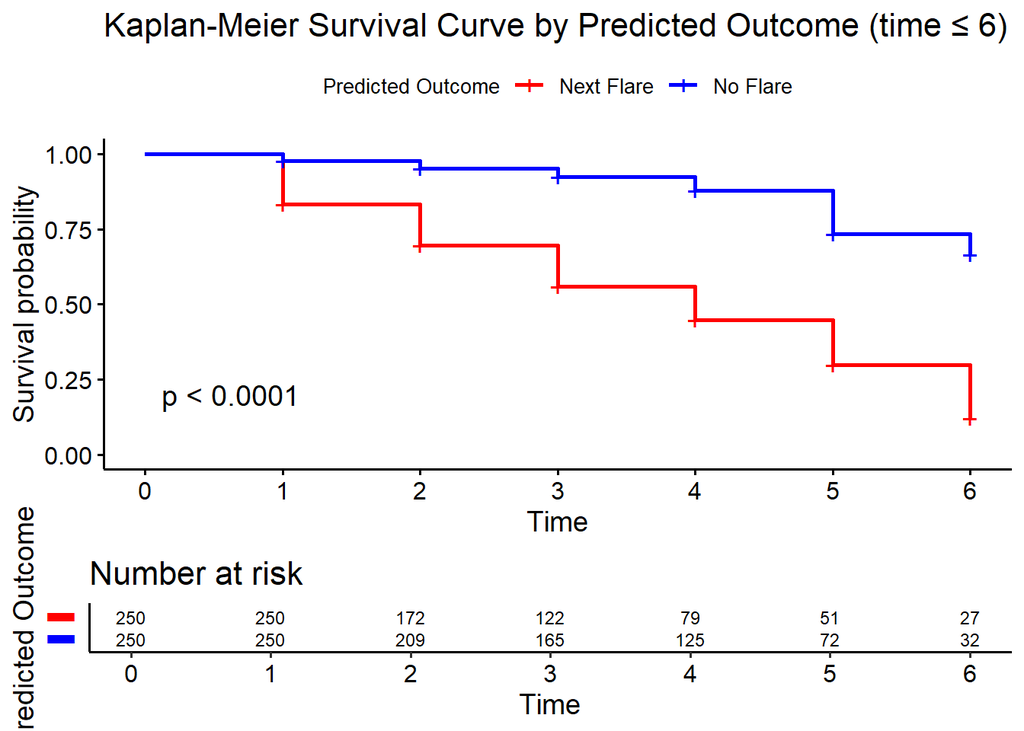

```r
# chunk5: Kaplan-Meier Survival Curve based on time ≤ 6


df_binary_km <- df_cox_filtered %>%
  filter(time <= 6)


cutoff_km <- median(df_binary_km$risk_score, na.rm = TRUE)
df_binary_km$risk_group <- ifelse(df_binary_km$risk_score > cutoff_km, "Next Flare", "No Flare")
df_binary_km$risk_group <- factor(df_binary_km$risk_group, levels = c("Next Flare", "No Flare"))


fit <- survfit(Surv(time, status) ~ risk_group, data = df_binary_km)


ggsurvplot(
  fit,
  data = df_binary_km,
  pval = TRUE,
  risk.table = TRUE,
  break.time.by = 1,
  risk.table.height = 0.25,
  risk.table.y.text.col = TRUE,
  risk.table.y.text = FALSE,
  risk.table.fontsize = 3,
  legend.title = "Predicted Outcome",
  legend.labs = c("Next Flare", "No Flare"),
  palette = c("red", "blue"),
  title = "Kaplan-Meier Survival Curve by Predicted Outcome (time ≤ 6)"
)
```

# 5. Time dependent AUC analysis (time-dependent ROC)

```r
# chunk6:


library(timeROC)


df_cox_filtered$risk_score <- predict(cox_model, type = "risk")


df_auc <- df_cox_filtered %>%
  filter(!is.na(time) & !is.na(status) & !is.na(risk_score))


valid_times <- df_auc %>%
  group_by(time) %>%
  summarise(
    total = n(),
    flare = sum(status)
  ) %>%
  filter(flare >= 10, total >= 30) %>%
  pull(time)


time_roc <- timeROC(
  T = df_auc$time,
  delta = df_auc$status,
  marker = df_auc$risk_score,
  cause = 1,
  times = valid_times,
  iid = TRUE
)


data.frame(
  Time = valid_times,
  AUC = round(time_roc$AUC, 3)
)
```

```
    Time   AUC
t=1    1    NA
t=2    2 0.841
t=3    3 0.823
t=4    4 0.796
t=5    5 0.778
t=6    6 0.760
t=7    7 0.769
```

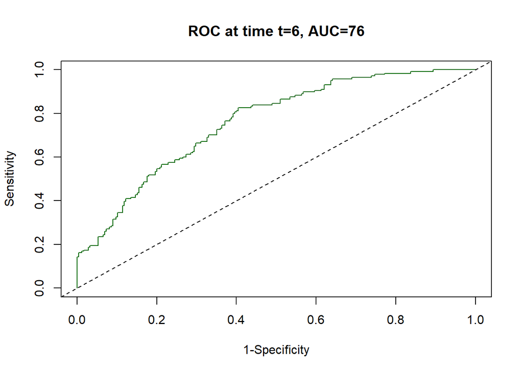

```r
plot(time_roc, time = valid_times[6], col = "darkgreen", title = TRUE)
```

# 6. Pseudo-Binary Classification Evaluation Based on Risk Score

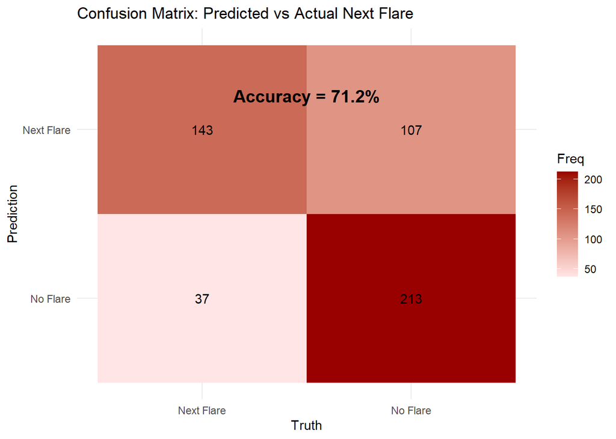

```r
# chunk8: Pseudo-Binary Classification Evaluation


df_binary <- df_cox_filtered %>%
  filter(time <= 6)


library(yardstick)
library(ggplot2)


df_binary_vis <- df_binary %>%
  mutate(
    Predicted = factor(ifelse(risk_score > median(risk_score, na.rm = TRUE), "Next Flare", "No Flare"),
                       levels = c("Next Flare", "No Flare")),
    Actual = factor(ifelse(status == 1, "Next Flare", "No Flare"),
                    levels = c("Next Flare", "No Flare"))
  )


cm <- conf_mat(df_binary_vis, truth = Actual, estimate = Predicted)


autoplot(cm, type = "heatmap") +
  scale_fill_gradient(low = "#FFE5E5", high = "#990000") +
  ggtitle("Confusion Matrix: Predicted vs Actual Next Flare") +
  annotate("text", x = 1.5, y = 2.2,
           label = paste0("Accuracy = ",
                          round((cm$table[1,1] + cm$table[2,2]) / sum(cm$table) * 100, 1), "%"),
           size = 5, fontface = "bold") +
  theme_minimal()
```

```r
df_binary_vis %>%
  metrics(truth = Actual, estimate = Predicted)
```

```
# A tibble: 2 × 3
  .metric  .estimator .estimate
  <chr>    <chr>          <dbl>
1 accuracy binary         0.712
2 kap      binary         0.424
```

# 7. Add more clinical variables to adjust the model parameters (not changed)

Create new variables - Calculate immune system subtypes

```r
df_cox_filtered <- df_cox_filtered %>%
  mutate(
    neutrophil_count = as.numeric(neutrophil_count),
    lymphocyte_count = as.numeric(lymphocyte_count)
  )


df_cox_filtered <- df_cox_filtered %>%
  mutate(
    immune_type = case_when(
      neutrophil_count > median(neutrophil_count, na.rm = TRUE) &
        lymphocyte_count <= median(lymphocyte_count, na.rm = TRUE) ~ "Innate-dominant",
      lymphocyte_count > median(lymphocyte_count, na.rm = TRUE) &
        neutrophil_count <= median(neutrophil_count, na.rm = TRUE) ~ "Adaptive-dominant",
      TRUE ~ "Mixed"
    )
  )


immune_table <- df_cox_filtered %>%
  group_by(`Immune Type` = immune_type) %>%
  summarise(Count = n(), .groups = "drop")

datatable(
  immune_table,
  caption = "Immune Subtype Distribution",
  options = list(dom = 't', autoWidth = TRUE)
)
```

|  | Immune Type | Count |
| --- | --- | --- |
| 1 | Adaptive-dominant | 162 |
| 2 | Innate-dominant | 163 |
| 3 | Mixed | 420 |

```r
library(survival)
library(broom)
library(DT)


df_cox_filtered$immune_type <- factor(df_cox_filtered$immune_type)

cox_formula_immune <- as.formula(
  paste("Surv(time, status) ~ sledai + immune_type +", paste(sprintf("`%s`", genes_to_use), collapse = " + "))
)


cox_model_immune <- coxph(cox_formula_immune, data = df_cox_filtered)


cox_result_immune <- tidy(cox_model_immune) %>%
  mutate(
    Hazard_Ratio = exp(estimate),
    Significance = case_when(
      p.value < 0.001 ~ "***",
      p.value < 0.01  ~ "**",
      p.value < 0.05  ~ "*",
      p.value < 0.1   ~ ".",
      TRUE ~ ""
    )
  ) %>%
  select(
    Variable = term,
    Coefficient = estimate,
    `Hazard Ratio` = Hazard_Ratio,
    `Std. Error` = std.error,
    `Z value` = statistic,
    `P-value` = p.value,
    Significance
  )


model_perf_immune <- data.frame(
  Metric = c("Concordance", "Likelihood Ratio Test (p)", "Wald Test (p)", "Score Test (p)"),
  Value = c(
    round(summary(cox_model_immune)$concordance[1], 3),
    signif(summary(cox_model_immune)$logtest["pvalue"], 3),
    signif(summary(cox_model_immune)$waldtest["pvalue"], 3),
    signif(summary(cox_model_immune)$sctest["pvalue"], 3)
  )
)

datatable(
  model_perf_immune,
  caption = "Table: Cox Model Performance Metrics (with Immune Type)",
  options = list(dom = 't', autoWidth = TRUE)
)
```

|  | Metric | Value |
| --- | --- | --- |
| 1 | Concordance | 0.775 |
| 2 | Likelihood Ratio Test (p) | 2.27e-22 |
| 3 | Wald Test (p) | 5.16e-26 |
| 4 | Score Test (p) | 1.13e-29 |